# 1_12

## Multilabel and Multioutput Algorithms

#### 1. Multilabel Classification

- Labeling each sample with **m** labels from **n_classes** possible classes
- **m** can be **0** to **n_classes** inclusive
- Comparable to running n_classes binary classification tasks, a binary output is assigned to each class, for every sample

#### 1.1 Multioutput Classifier

- Some classifiers in sklearn support multilabel, such as KNeighborsClassifier, RandomForestClassifier, do not need use multioutput classifier
- If a classifier do not support multilabel, such as LogisticRegression, need use multioutput classifier

```python
from sklearn.datasets import load_digits
digits = load_digits()
X = digits.data
y = digits.target
```

```python
from sklearn.model_selection import train_test_split
train_X, test_X, train_Y, test_Y = train_test_split(X, y, test_size=0.2, random_state=42, stratify = y)
```

```python
import numpy as np
y_train_large = (train_Y >= 7)
y_train_odd = (train_Y % 2 == 1)
y_multilabel = np.c_[y_train_large, y_train_odd] # create multiple labels
```

```python
# by default, KNeighborsClassifier in sklearn supports multilabel
from sklearn.neighbors import KNeighborsClassifier
from sklearn.ensemble import RandomForestClassifier
model = RandomForestClassifier(random_state=1)
model.fit(train_X, y_multilabel)

y_pred = model.predict(test_X) # 360*2
```

```python
from sklearn.multioutput import MultiOutputClassifier
forest = RandomForestClassifier(random_state=1)
model = MultiOutputClassifier(forest, n_jobs=-1)
model.fit(train_X, y_multilabel)

y_pred = model.predict(test_X) # 360*2
```

```python
from sklearn.linear_model import LogisticRegression
lr = LogisticRegression(random_state=0)
model = MultiOutputClassifier(lr, n_jobs=-1)
model.fit(train_X, y_multilabel)

y_pred = model.predict(test_X) # 360*2
```

#### 1.2 Classifier Chain

- Combine a number of binary classifiers into a single multi-label model
- Each model makes a prediction in the order specified by the chain using all of the available features provided to the model plus the predictions of models that are earlier in the chain

```python
from sklearn.multioutput import ClassifierChain
model = RandomForestClassifier(random_state=1)

chain = ClassifierChain(model, order='random', random_state=0)
chain.fit(train_X, y_multilabel)

y_pred = chain.predict(test_X) # 360*2
```

#### 2. Multioutput Regression

- predicts multiple numerical properties for each sample

#### 2.1 Multioutput Regressor

```python
from sklearn.datasets import make_regression
X, y = make_regression(n_samples=10, n_targets=3, random_state=1)
```

```python
from sklearn.ensemble import GradientBoostingRegressor
from sklearn.multioutput import MultiOutputRegressor

# MultiOutputRegressor, fits one regressor per target it can not take advantage of correlations between targets
model = MultiOutputRegressor(GradientBoostingRegressor(random_state=0))
model.fit(X, y)

model.predict(X)
```

```
array([[-154.75474165, -147.03498585,  -50.03812219],
       [   7.12165031,    5.12914884,  -81.46081961],
       [-187.8948621 , -100.44373091,   13.88978285],
       [-141.62745778,   95.02891072, -191.48204257],
       [  97.03260883,  165.34867495,  139.52003279],
       [ 123.92529176,   21.25719016,   -7.84253   ],
       [-122.25193977,  -85.16443186, -107.12274212],
       [ -30.170388  ,  -94.80956739,   12.16979946],
       [ 140.72667194,  176.50941682,  -17.50447799],
       [ 149.37967282,  -81.15699552,   -5.72850319]])
```

#### 2.2 Regressor Chain

- Combining a number of regressions into a single multi-target model
- Each model makes a prediction in the order specified by the chain using all of the available features provided to the model plus the predictions of models that are earlier in the chain.

```python
from sklearn.multioutput import RegressorChain
from sklearn.linear_model import LogisticRegression
model = GradientBoostingRegressor()
chain = RegressorChain(base_estimator=model)
chain.fit(X, y)

chain.predict(X)
```

[output not shown]

#### 3. Multiclass-multioutput Classification

- Multitask classification
- Labels each sample with a set of non-binary properties
- All classifiers handling multiclass-multioutput support the multilabel classification task as a special case
- Currently no Multiclass-multioutput classification class defined in sklearn like MultiOutputClassifier and MultiOutputRegressor

```python
digits = load_digits()
X = digits.data
y = digits.target

train_X, test_X, train_Y, test_Y = train_test_split(X, y, test_size=0.2, random_state=42, stratify = y)
```

```python
noise = np.random.randint(0, 3, (len(train_X), 64))
X_train_mod = train_X + noise
noise = np.random.randint(0, 3, (len(test_X), 64))
X_test_mod = test_X + noise
y_train_mod = train_X
y_test_mod = test_X
```

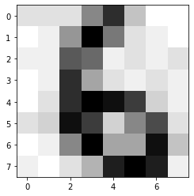

```python
import matplotlib
import matplotlib.pyplot as plt
plt.imshow(X_test_mod[100].reshape(8, 8), cmap = matplotlib.cm.binary, interpolation='nearest')
```

```python
# by default, KNeighborsClassifier in sklearn supports multiclass-multioutput classification
knn_clf = KNeighborsClassifier()
knn_clf.fit(X_train_mod, y_train_mod)

clean_digit = knn_clf.predict([X_test_mod[100]])
```

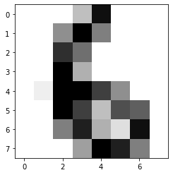

```python
plt.imshow(clean_digit.reshape(8, 8), cmap = matplotlib.cm.binary, interpolation='nearest')
```